# Lighthouse - Desafio

Ricardo Augusto Dias Gonçalves Souza

2023-07-27

# Análise Exploratória de Dados.

Começamos a análise exploratória observando as estatísticas descritivas de todas as variáveis

```r
summary(train)
```

```
##        id              num_fotos        marca              modelo
##  Min.   :1.333e+34   Min.   : 8.00   Length:29584       Length:29584
##  1st Qu.:8.618e+37   1st Qu.: 8.00   Class :character   Class :character
##  Median :1.707e+38   Median : 8.00   Mode  :character   Mode  :character
##  Mean   :1.706e+38   Mean   :10.32
##  3rd Qu.:2.555e+38   3rd Qu.:14.00
##  Max.   :3.403e+38   Max.   :21.00
##                      NA's   :177
##     versao          ano_de_fabricacao   ano_modelo     hodometro
##  Length:29584       Min.   :1985      Min.   :1997   Min.   :   100
##  Class :character   1st Qu.:2015      1st Qu.:2016   1st Qu.: 31214
##  Mode  :character   Median :2018      Median :2018   Median : 57434
##                     Mean   :2017      Mean   :2018   Mean   : 58431
##                     3rd Qu.:2019      3rd Qu.:2020   3rd Qu.: 81954
##                     Max.   :2022      Max.   :2023   Max.   :390065
##
##     cambio            num_portas        tipo             blindado
##  Length:29584       Min.   :2.000   Length:29584       Length:29584
##  Class :character   1st Qu.:4.000   Class :character   Class :character
##  Mode  :character   Median :4.000   Mode  :character   Mode  :character
##                     Mean   :3.941
##                     3rd Qu.:4.000
##                     Max.   :4.000
##
##      cor            tipo_vendedor      cidade_vendedor    estado_vendedor
##  Length:29584       Length:29584       Length:29584       Length:29584
##  Class :character   Class :character   Class :character   Class :character
##  Mode  :character   Mode  :character   Mode  :character   Mode  :character
##
##
##
##
##   anunciante        entrega_delivery   troca         elegivel_revisao
##  Length:29584       Mode :logical    Mode :logical   Mode :logical
##  Class :character   FALSE:23601      FALSE:24523     FALSE:29584
##  Mode  :character   TRUE :5983       TRUE :5061
##
##
##
##
```

[output cut: 9 more lines]

```
##  Length:29584       Length:29584       Length:29584
##  Class :character   Class :character   Class :character
##  Mode  :character   Mode  :character   Mode  :character
##
##
##
##
##  revisoes_dentro_agenda veiculo_alienado     preco
##  Length:29584           Mode:logical     Min.   :   9870
##  Class :character       NA's:29584       1st Qu.:  76572
##  Mode  :character                        Median : 114356
##                                          Mean   : 133024
##                                          3rd Qu.: 163680
##                                          Max.   :1359813
##
```

Já de cara podemos observar que a variável “veículo_alienado” contém apenas NAs. O que significa que em um primeiro momento é sábio retirá-la do restante das análises e, principalmente, do modelo, dado que não terá influência nas demais variáveis e na variável preço(target).

Também faz sentido verificar a correlação entre as variáveis numéricas e a variável preço. Podemos observar que o ano de fabricação e o hodômetro são as variáveis que mais impactam. A variável “id” é irrelevante aqui.

Também já percebemos que vale retirar das análises a variável “ano_modelo” dado que é quase que um proxy de “ano_de_fabricacao”, sendo menos straight-forward.

```r
numericos <- train[, sapply(train, is.numeric)]

cor_preco <- cor(numericos)

cor_preco <- cor_preco[,"preco"]

cor_preco <- sort(cor_preco, decreasing = TRUE)

print(cor_preco)
```

```
##             preco ano_de_fabricacao        ano_modelo                id
##       1.000000000       0.239171859       0.214853729      -0.004499568
##        num_portas         hodometro
##      -0.075264669      -0.359218059
```

A correlação das variáveis citadas pode ser observada visualmente:

Aqui podemos conferir que conforme o valor do hodometro aumenta, o preço cai. Conforme esperado e corroborado pelos dados

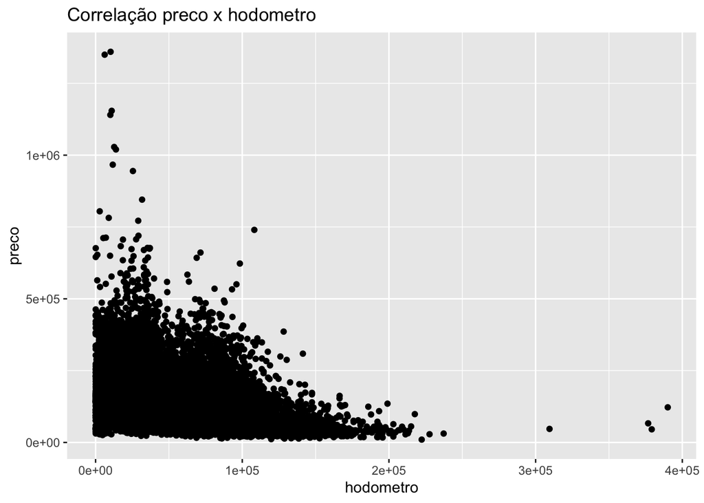

```r
ggplot(train, aes(x = hodometro, y = preco)) +
  geom_point() +
  labs(title = "Correlação preco x hodometro")
```

Já quanto ao ano de fabricação, quanto mais novo for o veículo maior seu valor. Também conforme esperado.

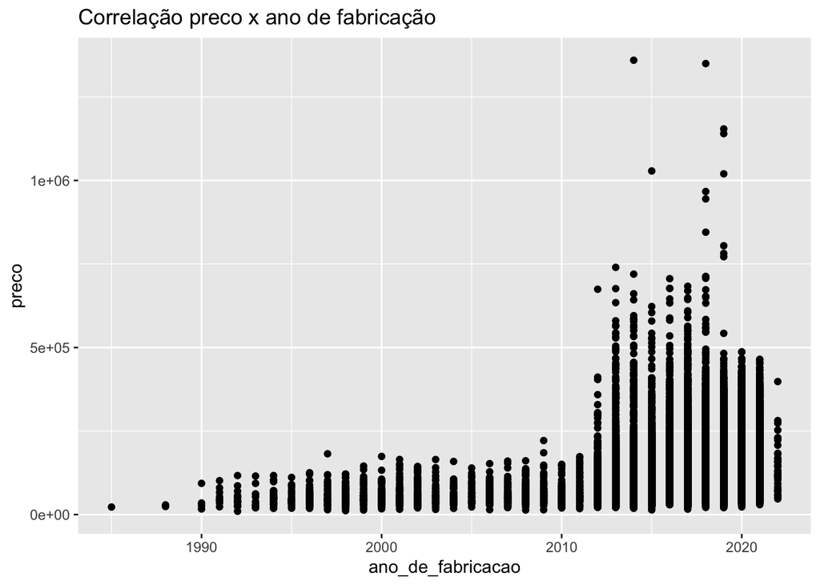

```r
ggplot(train, aes(x = ano_de_fabricacao, y = preco)) +
  geom_point() +
  labs(title = "Correlação preco x ano de fabricação")
```

# Perguntas item 2)

## 2) a) Qualo melhor estado cadastrado na base de dados para se vende rum carro de marca popular e por quê?

Para responder essa pergunta, consideraremos que o “melhor estado” para se vender um carro é aquele que tem o preço médio maior. Entretanto, é necessário filtrar os dados apenas para carros populares primeiro.

Utilizaremos dois critérios para selecionar carros populares.

1. A marca do automóvel
2. O valor, consideraremos apenas veículos com preço menor ou igual a R$ 70.000

Para isso filtramos pela coluna “marca”.

```r
carros_populares <- c("FIAT", "RENAULT", "PEUGEOT", "VOLKSWAGEN", "HYUNDAI")

populares <- train %>%
  filter(marca %in% carros_populares, preco <= 70000)

media_precos <- populares %>%
  group_by(estado_vendedor) %>%
  summarise(media_preco = mean(preco))


# Descobrir o estado com o maior preço médio
melhor_UF_venda <- media_precos$estado_vendedor[which.max(media_precos$media_preco)]


# Descobrir o maior preço médio
melhor_preco_venda <- media_precos$media_preco[which.max(media_precos$media_preco)]



cat("O melhor estado para se vender um carro popular é então", melhor_UF_venda, "com preço médio de R$", melhor_preco_venda, "\n")
```

```
## O melhor estado para se vender um carro popular é então Mato Grosso (MT) com preço médio de R$ 61957.46
```

## 2) b) Qual o melhor estado para se comprar uma picape com transmissão automática e por quê?

Parecido com a abordagem anterior, simplesmente filtraremos as colunas “tipo” e “cambio”. Obs: Será considerada apenas a transmissão automática, não o cambio CVT

```r
picapes <- train %>%
  filter(tipo == "Picape", cambio == "Automática")

media_compra <- picapes %>%
  group_by(estado_vendedor) %>%
  summarise(media_preco = mean(preco))


# Descobrir o estado com o maior preço médio
melhor_UF_compra <- media_compra$estado_vendedor[which.min(media_compra$media_preco)]


# Descobrir o maior preço médio
melhor_preco_compra <- media_compra$media_preco[which.min(media_compra$media_preco)]


cat("O melhor estado para se comprar uma picape com transmissão automática é", melhor_UF_compra, "com preço médio de R$", melhor_preco_compra, "\n")
```

```
## O melhor estado para se comprar uma picape com transmissão automática é Paraíba (PB) com preço médio de R$ 93157.04
```

## 2) c) Qual o melhor estado para se comprar carros que ainda estejam dentro da garantia de fábrica e por quê?

Novamente, iremos pela abordagem de filtrar os dados e então procurar pela UF com menor preço médio.

Nesse caso precisamos apenas saber se o carro ainda está na garantia, o que pode ser feito pela coluna “garantia_de_fábrica”

```r
garantia <- train %>%
  filter(garantia_de_fábrica == "Garantia de fábrica")


media_garantia <- garantia %>%
  group_by(estado_vendedor) %>%
  summarise(media_preco = mean(preco))


# Descobrir o estado com o maior preço médio
melhor_UF_garantia <- media_garantia$estado_vendedor[which.min(media_garantia$media_preco)]


# Descobrir o maior preço médio
melhor_preco_garantia <- media_garantia$media_preco[which.min(media_garantia$media_preco)]


cat("O melhor estado para se comprar uma picape com transmissão automática é", melhor_UF_garantia, "com preço médio de R$", melhor_preco_garantia, "\n")
```

```
## O melhor estado para se comprar uma picape com transmissão automática é Paraíba (PB) com preço médio de R$ 95762.75
```

# Rodando o modelo

```r
train_limpo <- train %>%
  mutate(entrega_delivery = as.numeric(entrega_delivery), troca = as.numeric(troca), elegivel_revisao = as.numeric(elegivel_revisao))


modelo_2 <- lm(preco ~ hodometro + ano_de_fabricacao + num_portas + entrega_delivery + troca, data = train)


summary(modelo_2)
```

```
##
## Call:
## lm(formula = preco ~ hodometro + ano_de_fabricacao + num_portas +
##     entrega_delivery + troca, data = train)
##
## Residuals:
##     Min      1Q  Median      3Q     Max
## -182224  -49683  -14901   33502 1165822
##
## Coefficients:
##                        Estimate Std. Error t value Pr(>|t|)
## (Intercept)           1.478e+06  3.214e+05   4.597 4.30e-06 ***
## hodometro            -9.683e-01  1.976e-02 -49.002  < 2e-16 ***
## ano_de_fabricacao    -5.934e+02  1.591e+02  -3.729 0.000192 ***
## num_portas           -2.258e+04  1.303e+03 -17.324  < 2e-16 ***
## entrega_deliveryTRUE -2.312e+04  2.447e+03  -9.448  < 2e-16 ***
## trocaTRUE             1.328e+04  2.604e+03   5.101 3.39e-07 ***
## ---
## Signif. codes:  0 '***' 0.001 '**' 0.01 '*' 0.05 '.' 0.1 ' ' 1
##
## Residual standard error: 75600 on 29578 degrees of freedom
## Multiple R-squared:  0.1431, Adjusted R-squared:  0.1429
## F-statistic: 987.6 on 5 and 29578 DF,  p-value: < 2.2e-16
```